# Categorical variables and factors

09-01-2021

## Learning Goals

*At the end of this exercise, you will be able to:*  
1. Use the forcats package to manipulate factors, enabling a range of ways to handle categorical variables in your datasets.

## Questions

If you have question or need help with a specific problem, please email me.

## Intro

In prior sessions, we have learned how to use the `dplyr` package to manipulate dataframes in a number of useful ways - filtering, selecting, and more. We’ve also learned how to graph and display data in a number of ways with `ggplot2`. To add to these abilities, it would be useful to be able to work seamlessly with categorical data - where the values are text-based categories, rather than numbers. To do this, we’ll take a closer look at the `forcats` package.

## Install the `forcats` package

```r
#install.packages("forcats")
```

## Load the `tidyverse`, `forcats`, and `ggplot2`

```r
library("tidyverse")
library("forcats")
library("ggplot2")
```

## Load the data

For these exercises we will continue using the data from the previous meeting - the “workshop_wide.csv” file.

```r
edu_dat <- read_csv("workshop_wide.csv")
```

Let’s remind ourselves what the data look like - what variables appear to be categorical?

```r
glimpse(edu_dat)
```

```
## Rows: 600
## Columns: 20
## $ id           <dbl> 1, 2, 3, 4, 5, 6, 7, 8, 9, 10, 11, 12, 13, 14, 15, 16, 17…
## $ year         <dbl> 2017, 2017, 2017, 2016, 2016, 2016, 2016, 2017, 2016, 201…
## $ likert1_pre  <chr> "Strongly agree", "Agree", "Neutral", "Strongly agree", "…
## $ likert2_pre  <chr> "Neutral", "Agree", "Agree", "Strongly agree", "Neutral",…
## $ likert3_pre  <chr> "Agree", "Neutral", "Agree", "Strongly disagree", "Strong…
## $ likert4_pre  <chr> NA, NA, NA, NA, NA, NA, NA, NA, NA, "Agree", "Agree", "Ne…
## $ likert1_post <chr> "Agree", "Strongly agree", "Strongly agree", "Agree", "St…
## $ likert2_post <chr> "Disagree", "Neutral", "Strongly disagree", "Disagree", "…
## $ likert3_post <chr> "Neutral", "Neutral", "Agree", "Disagree", "Strongly agre…
## $ likert4_post <chr> "Disagree", "Neutral", "Agree", "Neutral", "Agree", "Agre…
## $ mc1_pre      <chr> NA, "C", "D", "C", "C", "C", "C", "C", "A", "C", "C", "C"…
## $ mc2_pre      <chr> "C", "A", "A", "A", "B", "B", "A", "B", "B", "D", "B", "B…
## $ mc1_post     <chr> "D", "C", "C", "C", NA, "B", "C", "C", NA, "C", "C", "C",…
## $ mc2_post     <chr> "A", "A", "A", "A", "C", "A", "A", "A", "A", "A", "A", "D…
## $ course       <chr> "course_2", "course_2", "course_2", "course_1", "course_1…
## $ gender       <chr> "F", "F", "F", "M", "F", "F", "F", "F", "F", "F", "F", "F…
## $ gpa_prior    <dbl> 2.94, 3.19, 3.45, 3.08, 3.05, 3.05, 3.29, 3.44, 3.55, 3.2…
## $ admit_level  <chr> "Freshman", "Freshman", "Freshman", "Freshman", "Transfer…
## $ final_exam   <dbl> 70, 71, 53, 64, 66, 60, 62, 77, 67, 61, 62, 69, 72, 61, 5…
## $ PEER         <chr> "no", "yes", "no", "yes", "yes", "no", "no", "yes", "yes"…
```

## Why convert from character to factor?

First, let’s look at the frequency of counts within the “likert1_pre” variable.

```r
table(edu_dat$likert1_pre)
```

```
##
##          Agree       Disagree        Neutral Strongly agree
##            353              4             73            170
```

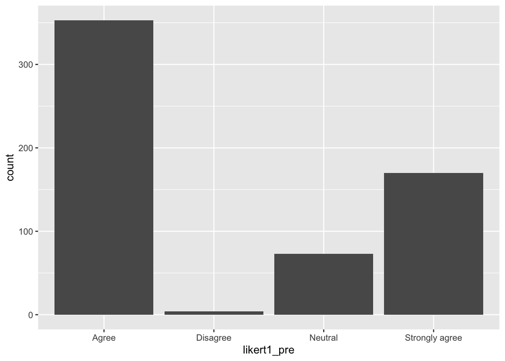

```r
ggplot(edu_dat, aes(likert1_pre)) +
  geom_bar()
```

What things do you notice about this graph and table? What might we want to change about it?

First, the ordering of the x-axis is not particularly helpful to our interpretation. This is currently in alphabetical order. There are two ways that this might be easier to interpret - either we can order the bars in ascending/descending order of frequency, or we can order them in terms of the meaningful sequencing that these likert scale items have. Here, “Strongly agree” is on one end of the spectrum, “Strongly disagree” is on the other end, and “Neutral” is in the middle.

In order to sequence things using the natural ordering or meaningful sequencing of a categorical variable, we can define the variable as a factor with levels.

To do this for likert1_pre, first we can define the levels in a logical order.

```r
likert_levels <- c("Strongly agree", "Agree", "Neutral", "Disagree", "Strongly disagree")
```

Now, let’s create a factor using these levels.

```r
likert1_pre_factor <- factor(edu_dat$likert1_pre, levels = likert_levels)
```

Now, let’s try looking at this variable again…

```r
table(likert1_pre_factor)
```

```
## likert1_pre_factor
##    Strongly agree             Agree           Neutral          Disagree
##               170               353                73                 4
## Strongly disagree
##                 0
```

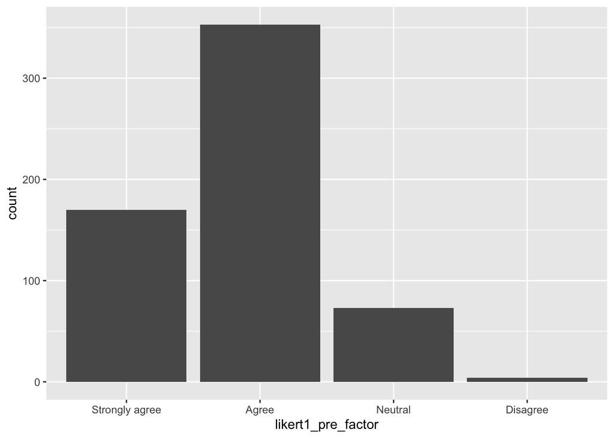

```r
ggplot(edu_dat, aes(likert1_pre_factor)) +
  geom_bar()
```

How does this table and plot differ from the first set we made? Are these changes helpful? Is there anything more we might want to be able to do?

Now, the left side of the graph shows stronger agreement, and the right moves towards disagreement. This might be a bit easier for a viewer to interpret quickly and accurately! The one thing that is missing here in the plot (but is fine in the table)- we have one level (Strongly disagree) that is not represented. We may still want to plot that level for completeness. This would be even more useful to consider if it was say “Disagree” that was missing, without any visual indication that there was something between “Neutral” and “Strongly Disagree”.

Let’s try to display our “missing” level on our graph.

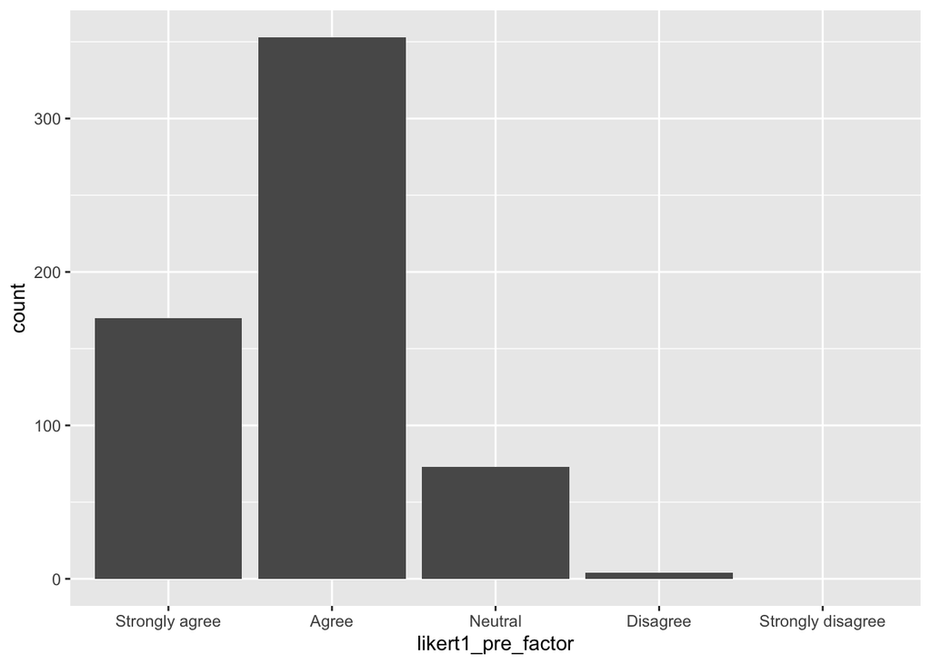

```r
ggplot(edu_dat, aes(likert1_pre_factor)) +
  geom_bar() +
  scale_x_discrete(drop=FALSE)
```

## Factors within data tables

For this first example, we created a factor from a variable in our edu_dat data table, but we didn’t change the likert1_pre variable to be a factor in the data table itself. What if we want to convert our data table into one containing factors in place of character variables?

```r
edu_dat$likert1_pre <- factor(edu_dat$likert1_pre)
glimpse(edu_dat)
```

```
## Rows: 600
## Columns: 20
## $ id           <dbl> 1, 2, 3, 4, 5, 6, 7, 8, 9, 10, 11, 12, 13, 14, 15, 16, 17…
## $ year         <dbl> 2017, 2017, 2017, 2016, 2016, 2016, 2016, 2017, 2016, 201…
## $ likert1_pre  <fct> Strongly agree, Agree, Neutral, Strongly agree, Neutral, …
## $ likert2_pre  <chr> "Neutral", "Agree", "Agree", "Strongly agree", "Neutral",…
## $ likert3_pre  <chr> "Agree", "Neutral", "Agree", "Strongly disagree", "Strong…
## $ likert4_pre  <chr> NA, NA, NA, NA, NA, NA, NA, NA, NA, "Agree", "Agree", "Ne…
## $ likert1_post <chr> "Agree", "Strongly agree", "Strongly agree", "Agree", "St…
## $ likert2_post <chr> "Disagree", "Neutral", "Strongly disagree", "Disagree", "…
## $ likert3_post <chr> "Neutral", "Neutral", "Agree", "Disagree", "Strongly agre…
## $ likert4_post <chr> "Disagree", "Neutral", "Agree", "Neutral", "Agree", "Agre…
## $ mc1_pre      <chr> NA, "C", "D", "C", "C", "C", "C", "C", "A", "C", "C", "C"…
## $ mc2_pre      <chr> "C", "A", "A", "A", "B", "B", "A", "B", "B", "D", "B", "B…
## $ mc1_post     <chr> "D", "C", "C", "C", NA, "B", "C", "C", NA, "C", "C", "C",…
## $ mc2_post     <chr> "A", "A", "A", "A", "C", "A", "A", "A", "A", "A", "A", "D…
## $ course       <chr> "course_2", "course_2", "course_2", "course_1", "course_1…
## $ gender       <chr> "F", "F", "F", "M", "F", "F", "F", "F", "F", "F", "F", "F…
## $ gpa_prior    <dbl> 2.94, 3.19, 3.45, 3.08, 3.05, 3.05, 3.29, 3.44, 3.55, 3.2…
## $ admit_level  <chr> "Freshman", "Freshman", "Freshman", "Freshman", "Transfer…
## $ final_exam   <dbl> 70, 71, 53, 64, 66, 60, 62, 77, 67, 61, 62, 69, 72, 61, 5…
## $ PEER         <chr> "no", "yes", "no", "yes", "yes", "no", "no", "yes", "yes"…
```

Okay, so it looks like this works for our variable in question! Let’s try plotting things again to confirm:

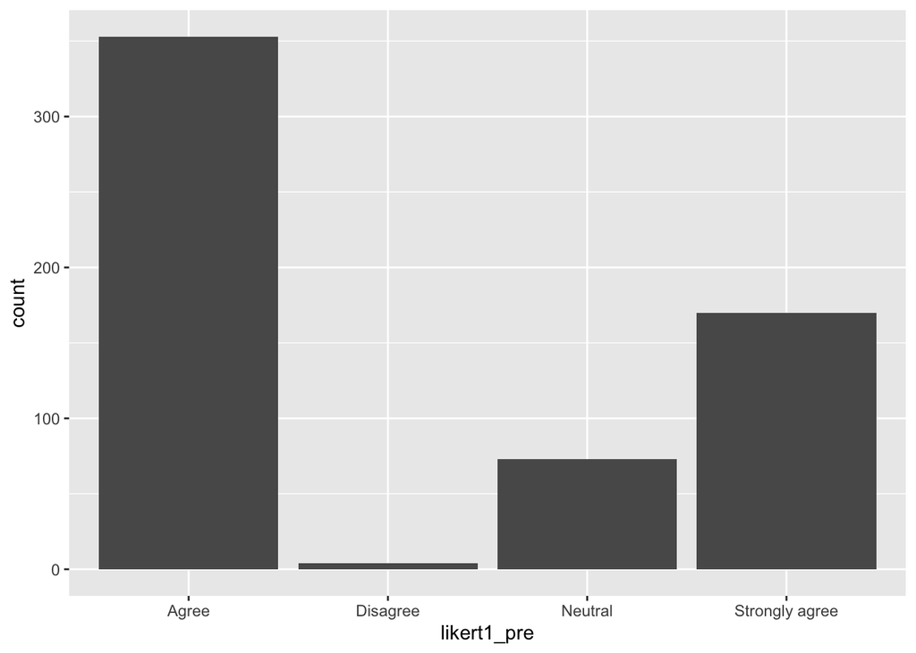

```r
ggplot(edu_dat, aes(likert1_pre)) +
  geom_bar()
```

Oh no! We thought we converted to a factor - what happened? We didn’t define the level ordering, and R will default to alphabetical if you don’t tell it otherwise.

Let’s try to set the levels to fix our data table…

```r
edu_dat$likert1_pre <- factor(edu_dat$likert1_pre, levels = c("Strongly agree", "Agree", "Neutral","Disagree","Strongly disagree"))
```

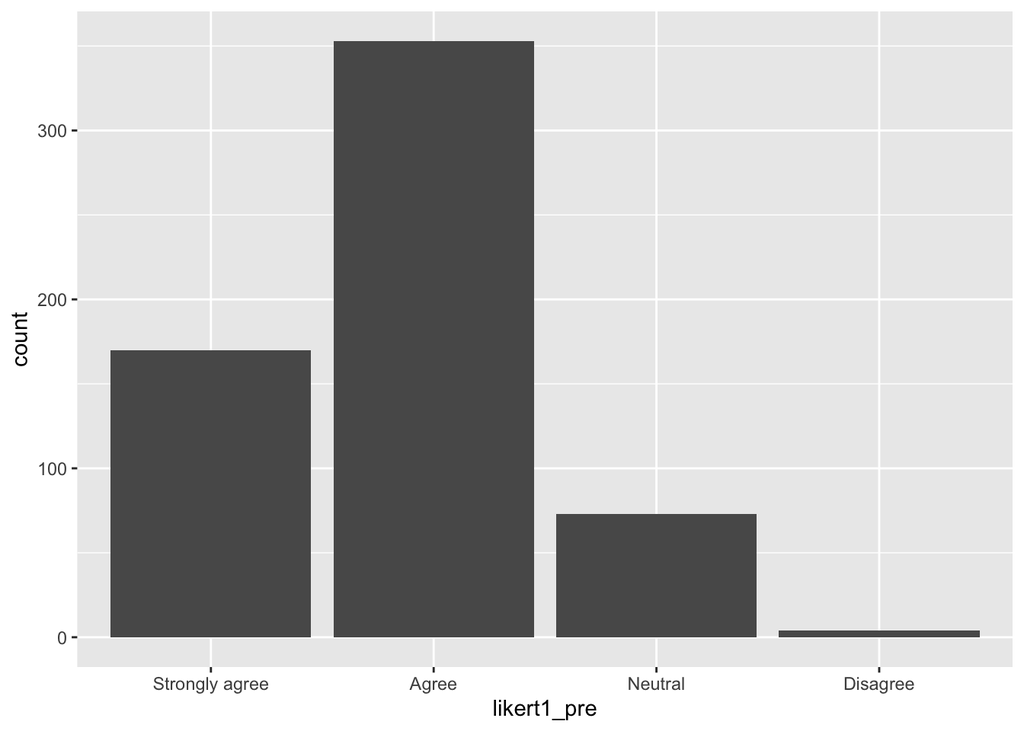

```r
ggplot(edu_dat, aes(likert1_pre)) +
  geom_bar()
```

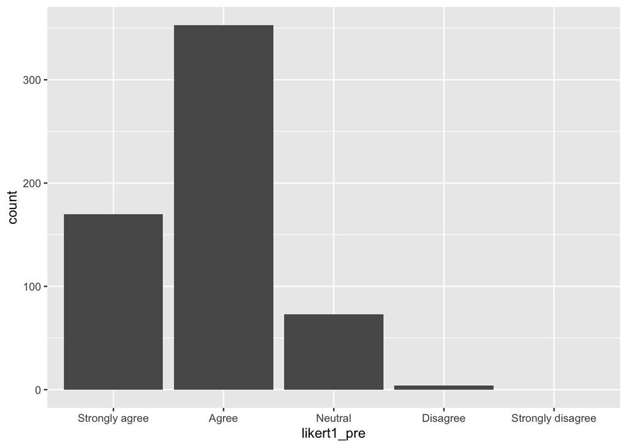

```r
ggplot(edu_dat, aes(likert1_pre)) +
  geom_bar() +
  scale_x_discrete(drop=FALSE)
```

What if we want to reorder the levels, so that the most frequent response comes first?

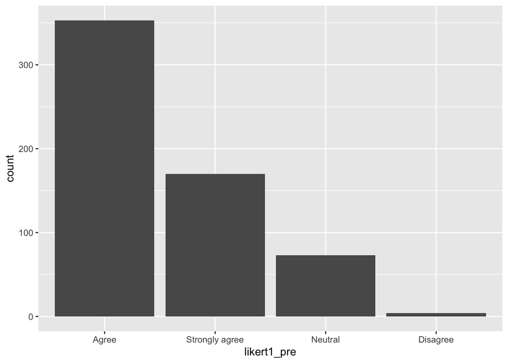

```r
edu_dat %>%
  mutate(likert1_pre = fct_infreq(likert1_pre)) %>%
ggplot(aes(x = likert1_pre)) +
 geom_bar()
```

What if we wanted to combine factor levels, so that we had three levels for our likert1_pre factor - one for general agreement, one for neutral, and one for general disagreement?

```r
edu_dat %>%
  mutate(likert1_pre = fct_recode(likert1_pre,
                                  "Generally agree" = "Strongly agree",
                                  "Generally agree" = "Agree",
                                  "Neutral" = "Neutral",
                                  "Generally disagree" = "Disagree",
                                  "Generally disagree" = "Strongly disagree"

                                  )) %>%
  count(likert1_pre)
```

```
## # A tibble: 3 × 2
##   likert1_pre            n
##   <fct>              <int>
## 1 Generally agree      523
## 2 Neutral               73
## 3 Generally disagree     4
```

As you can see, fct_recode is useful for both collapsing levels into groups, as well as for renaming factor levels on the fly.

## Practice in breakout rooms!

1. Take a look at edu_dat again. Identify at least 3 variables you could meaningfully convert to factors. Once you’ve decided what to convert, make it happen within the data table! How can you check to ensure the conversion happened?

```r
edu_dat$likert1_post <- factor(edu_dat$likert1_post)
edu_dat$admit_level <- factor(edu_dat$admit_level)
edu_dat$gender <- factor(edu_dat$gender)
glimpse(edu_dat)
```

```
## Rows: 600
## Columns: 20
## $ id           <dbl> 1, 2, 3, 4, 5, 6, 7, 8, 9, 10, 11, 12, 13, 14, 15, 16, 17…
## $ year         <dbl> 2017, 2017, 2017, 2016, 2016, 2016, 2016, 2017, 2016, 201…
## $ likert1_pre  <fct> Strongly agree, Agree, Neutral, Strongly agree, Neutral, …
## $ likert2_pre  <chr> "Neutral", "Agree", "Agree", "Strongly agree", "Neutral",…
## $ likert3_pre  <chr> "Agree", "Neutral", "Agree", "Strongly disagree", "Strong…
## $ likert4_pre  <chr> NA, NA, NA, NA, NA, NA, NA, NA, NA, "Agree", "Agree", "Ne…
## $ likert1_post <fct> Agree, Strongly agree, Strongly agree, Agree, Strongly ag…
## $ likert2_post <chr> "Disagree", "Neutral", "Strongly disagree", "Disagree", "…
## $ likert3_post <chr> "Neutral", "Neutral", "Agree", "Disagree", "Strongly agre…
## $ likert4_post <chr> "Disagree", "Neutral", "Agree", "Neutral", "Agree", "Agre…
## $ mc1_pre      <chr> NA, "C", "D", "C", "C", "C", "C", "C", "A", "C", "C", "C"…
## $ mc2_pre      <chr> "C", "A", "A", "A", "B", "B", "A", "B", "B", "D", "B", "B…
## $ mc1_post     <chr> "D", "C", "C", "C", NA, "B", "C", "C", NA, "C", "C", "C",…
## $ mc2_post     <chr> "A", "A", "A", "A", "C", "A", "A", "A", "A", "A", "A", "D…
## $ course       <chr> "course_2", "course_2", "course_2", "course_1", "course_1…
## $ gender       <fct> F, F, F, M, F, F, F, F, F, F, F, F, F, M, F, F, F, F, F, …
## $ gpa_prior    <dbl> 2.94, 3.19, 3.45, 3.08, 3.05, 3.05, 3.29, 3.44, 3.55, 3.2…
## $ admit_level  <fct> Freshman, Freshman, Freshman, Freshman, Transfer, Transfe…
## $ final_exam   <dbl> 70, 71, 53, 64, 66, 60, 62, 77, 67, 61, 62, 69, 72, 61, 5…
## $ PEER         <chr> "no", "yes", "no", "yes", "yes", "no", "no", "yes", "yes"…
```

2. Now that you’ve converted characters into factors, choose one of these factors and reorder the levels in a way that makes sense to you. Then, plot the frequency of the factor levels in question.

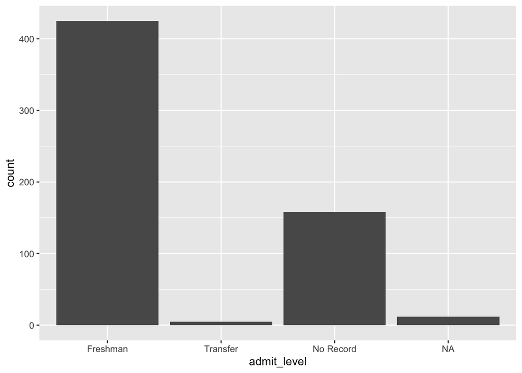

```r
levels(edu_dat$admit_level) <- c("Freshman", "Transfer", "No Record")
edu_dat %>%
ggplot(aes(x = admit_level)) +
 geom_bar()
```

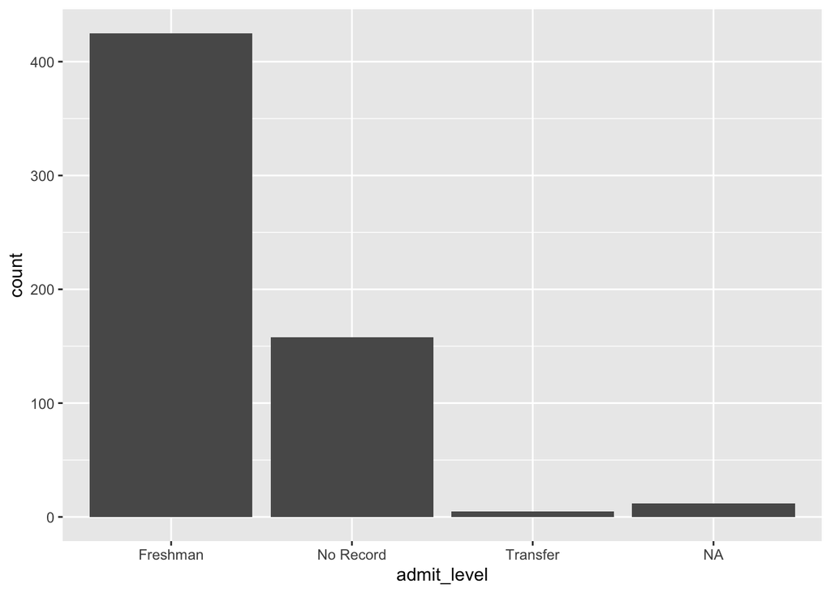

```r
edu_dat %>%
  mutate(admit_level = fct_infreq(admit_level)) %>%
ggplot(aes(x = admit_level)) +
 geom_bar()
```

3. Imagine you enacted a major curriculum redesign in 2018, and you’d like to compare final exam scores before the redesign with scores after the redesign. Use factors to accomplish this grouping and comparison - there’s more than one way to successfully display your results!

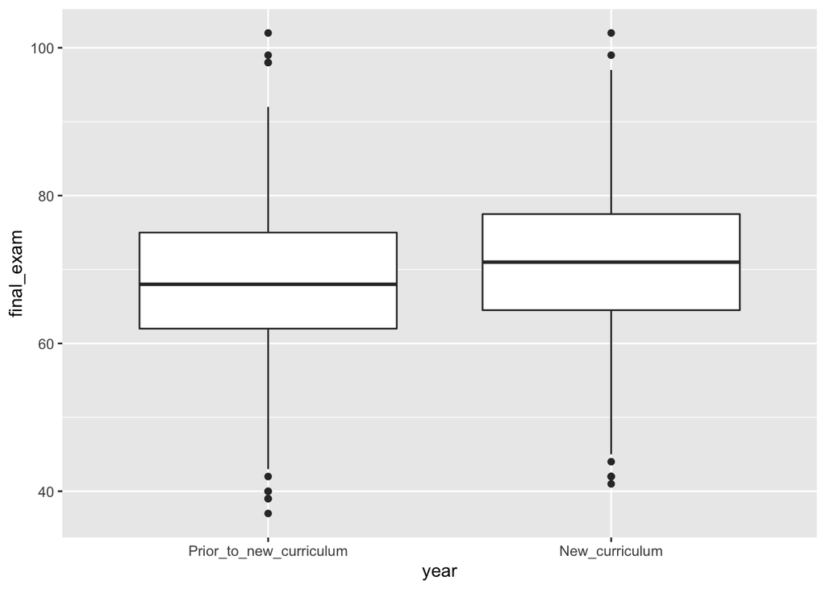

```r
edu_dat$year <- factor(edu_dat$year)
levels(edu_dat$year) <- c("2016", "2017", "2018", "2019")
edu_dat %>%
  mutate(year = fct_recode(year,
                                  "Prior_to_new_curriculum" = "2016",
                                  "Prior_to_new_curriculum" = "2017",
                                  "New_curriculum" = "2018",
                                  "New_curriculum" = "2019",
                                  )) %>%
  ggplot(aes(year,final_exam)) +
  geom_boxplot()
```

## Additional resources

Factors chapter in “R for Data Science” - https://r4ds.had.co.nz/factors.html

Official forcats “cheatsheet” - https://raw.githubusercontent.com/rstudio/cheatsheets/master/factors.pdf

That’s it for now - great work!